# Dissolved Oxygen in the Cache La Poudre

# Background

In late summer 2018, there was a large fish kill in the Cache La Poudre river in Fort Collins, Colorado. After that event, the City of Fort Collins and the Ross lab installed 6 water quality sensors in the river to get real-time water quality information. One key parameter these sensors measured was dissolved oxygen, because fish kills can be caused by low oxygen levels, sometimes called anoxic events. These events are caused by a variety of things, but often it is when water is slow moving, has a highly productive algal community in the river (or lake). These algae produce oxygen during the day but at night and when the waters cool, they die. Their decomposing bodies consume oxygen rapidly.

For this assignment we will explore controls on dissolved oxygen at a variety of sites in the Cache La Poudre.

## Site Map

```r
sites <- st_read('data/sondes.kml') %>%
  filter(Name != 'Manners Sonde (FC-existing)') %>%
  mutate(Name = factor(Name,levels=c('Rist Canyon Rd (CSU)',
                                     'Legacy (CSU)',
                                     'Lincoln (In-situ)',
                                     'Timberline (FC)',
                                     'Prospect (FC)',
                                     'ELC (CSU; online)',
                                     'Archery Range (FC)',
                                     'Fossil Creek (FC)')))
```

```
FALSE Reading layer `FC WQ Sondes (proposed)' from data source `/cloud/project/data/sondes.kml' using driver `LIBKML'
FALSE Simple feature collection with 9 features and 11 fields
FALSE geometry type:  POINT
FALSE dimension:      XYZ
FALSE bbox:           xmin: -105.2688 ymin: 40.50217 xmax: -104.9677 ymax: 40.69664
FALSE z_range:        zmin: 0 zmax: 0
FALSE CRS:            4326
```

```r
mapview(sites, zcol = 'Name', col.regions=c('#1b7837','#7fbf7b','gray',
                                        '#d9f0d3','#e7d4e8',
                                        '#af8dc3','#762a83','gray'
                                        ))
```

[interactive chart not shown]

### Question 1)

When thinking about controls on dissolved oxygen in rivers, what are three important gradients that change as you go from Rist Canyon to Archery Range? (hint use the different basemaps to explore the landscape)

## Dataset

For this project the City and the Ross Lab are measuring:

- Temperature
- Dissolved Oxygen (as % saturation and mg/l)
- Turbidity
- pH
- ORP (oxidation reduction potential)
- Water Level
- Specific Conductivity (salinity)

Here we will be looking at a subset of this sensor data for October, 2019.

```r
p_dat <- read_csv('data/oct_2019.csv')
```

## Site specific analysis

### Rist Canyon

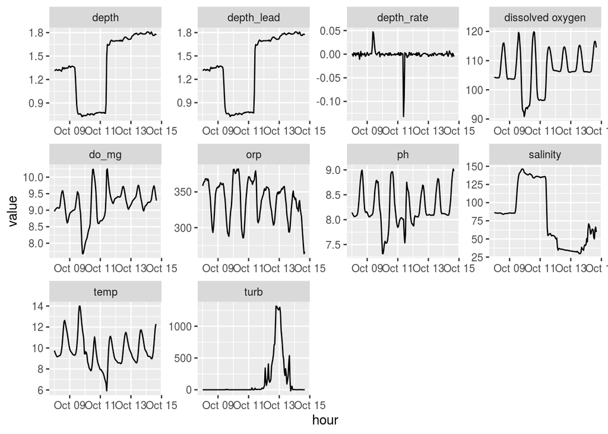

```r
rist_dat <- p_dat %>%
  filter(site == 'Rist',
         day(hour) > 7)

ggplot(data = rist_dat, aes(x = hour, y = value)) +
  geom_line() +
  facet_wrap(~sensor, scales = 'free')
```